# Module 3: AR and MA Processes

Econ 6376 — Applied Time Series Econometrics

## How to Use These Notes

This chapter has one main reading path and three optional layers.

- **Core** material is the main text. It contains the concepts, notation, interpretations, and applied skills expected of everyone.
- **Deeper Dive** sections explain why a result works or develop it more fully. They are useful, but they can be skipped on a first reading.
- **Technical Note** sections state qualifications or formal details that matter for precise reasoning.
- **Looking Ahead** sections introduce an idea that will be taught formally in a later module.

If you missed lecture, read the main text, run the Core code, and complete the Core Practice problems. Then return to the optional sections that address your questions or interests.

## Core Learning Objectives

By the end of this module, you should be able to:

1. Write down the AR(p), MA(q), and ARMA(p,q) data-generating processes in both summation and lag-polynomial form, using the course conventions for $\Phi(L)$ and $\Theta(L)$.
2. State the stationarity condition for an AR(p) as a condition on the roots of $\Phi(L)$, and apply it to AR(2) using the quadratic formula.
3. Distinguish AR(2) processes with real roots from those with complex roots, and connect the sign of the discriminant to the shape of the ACF.
4. Show algebraically that an MA(1) has $\rho_k = 0$ for $k \geq 2$, and generalize the cutoff intuition to MA(q).
5. State the invertibility condition for an MA(q), explain why it matters in plain language, and identify the over-differencing case from L2 as the canonical non-invertible example.
6. Explain the AR$\leftrightarrow$MA isomorphism: a stationary AR(p) is an MA($\infty$), an invertible MA(q) is an AR($\infty$), and a small finite ARMA is a compact code for infinite-order dynamics.
7. Define the partial autocorrelation function, contrast it with the ACF, and state the cut-off / tail-off rules for AR(p), MA(q), and ARMA(p,q).
8. Simulate AR(1), AR(2), MA(1), MA(2), and ARMA(1,1) processes in R, plot their ACFs and PACFs side by side, and identify each from its fingerprint.

## 3.1 Where We Are on the Mixing Board

In Module 1 we wrote down the master equation for the whole course:

$$y_t = \alpha + \delta t + \sum_{j=1}^{p} \phi_j y_{t-j} + \sum_{l=1}^{q} \theta_l \epsilon_{t-l} + \epsilon_t$$

and then immediately turned off most of it. We kept $\alpha$ and $\phi_1$, left every other lag silent, and studied the AR(1) for the rest of Module 1. Module 2 kept us in the same neighborhood — the Dickey-Fuller test rearranges the AR(1), and even the trend-augmented specification only turned on $\delta t$. At no point have we let $\phi_2$, $\phi_3$, or any of the $\theta_l$ do anything.

Module 2 also handed us two loose ends, and this module picks up both. First, the **over-differencing trap** named a boundary: differencing a trend-stationary series manufactured an MA(1) with $\theta = -1$ — a “unit root in the MA polynomial” — and we promised that Module 3 would define the property being violated (*invertibility*, §3.3.4) and probe it experimentally (§3.5.3). Second, Module 2’s power studies showed that formal tests cannot reliably separate $\phi = 0.95$ from $\phi = 1.0$ in realistic samples. This module adds a complementary tool that works alongside testing rather than replacing it: the **correlogram fingerprint** — reading ACF/PACF pairs to identify AR and MA structure.

Today we turn on the rest. By the end of this module you will have seen the full AR(p) summation, the full MA(q) summation, and the mixed ARMA(p,q) process that combines them. The only piece of the master equation you will *not* have seen formally is the seasonal block, and that waits until Module 5.

The mixing-board picture from Module 1 is worth drawing one more time, because we are about to move several of the sliders:

| Term | Status after L2 | Status after L3 |
| --- | --- | --- |
| $\alpha$ | On | On |
| $\delta t$ | On (in the trend ADF) | On |
| $\phi_1 y_{t-1}$ | On | On |
| $\phi_2 y_{t-2}, \ldots, \phi_p y_{t-p}$ | **Off** | **On** |
| $\theta_1 \epsilon_{t-1}, \ldots, \theta_q \epsilon_{t-q}$ | **Off** | **On** |
| $\epsilon_t$ | On | On |

### Two Kinds of Memory

Before the equations, the concept. AR processes and MA processes are both memory devices, but they remember different things.

- **AR memory** is memory of $y$ itself. The question “how many days of my own history matter for today?” is an AR question. An AR(p) remembers the last $p$ values of the series and lets every older shock influence the present *indirectly*, through those $y$’s.
- **MA memory** is memory of shocks. The question “how many recent surprises are still rattling around in the system?” is an MA question. An MA(q) explicitly carries the last $q$ innovations forward and then forgets them entirely.

A household-budget analogy. Let $y_t$ be your bank balance at the end of day $t$.

- An **AR(p)** bank balance depends on the last $p$ days’ balances — your standing orders, the rhythm of how you pay rent and get paid, the inertia of your existing commitments. If yesterday was a big day, today will be too; the pattern repeats because your schedule does.
- An **MA(q)** bank balance depends on the last $q$ unexpected windfalls and disasters — the surprise tax refund, the surprise car repair, the birthday check from your aunt — that haven’t yet washed through your account. Once they finish propagating, they are gone.
- Most real series are **ARMA**: both the rhythm of your past *and* the lingering effect of recent shocks.

Keep that image in your head. We will return to it at the end of every major section.

## 3.2 AR(p) Processes

### 3.2.1 Definition

The **AR(p) process** is the generalization of the AR(1) that uses $p$ lags of $y$ instead of one:

$$y_t = \alpha + \phi_1 y_{t-1} + \phi_2 y_{t-2} + \ldots + \phi_p y_{t-p} + \epsilon_t, \qquad \epsilon_t \sim \text{WN}(0, \sigma^2)$$

In summation form:

$$y_t = \alpha + \sum_{j=1}^{p} \phi_j y_{t-j} + \epsilon_t$$

And in the lag-operator notation from Module 1, using the course convention $\Phi(L) = 1 - \phi_1 L - \phi_2 L^2 - \ldots - \phi_p L^p$:

$$\Phi(L) y_t = \alpha + \epsilon_t$$

The minus signs in $\Phi(L)$ are not cosmetic. They come from the same move we made for the AR(1) in Module 1: subtract the AR terms from both sides to collect $y_t$ on the left.

$$y_t - \phi_1 y_{t-1} - \phi_2 y_{t-2} - \ldots - \phi_p y_{t-p} = \alpha + \epsilon_t$$

$$(1 - \phi_1 L - \phi_2 L^2 - \ldots - \phi_p L^p) y_t = \alpha + \epsilon_t$$

The minuses come for free the moment you move the $\phi_j y_{t-j}$ terms across the equals sign. The reference for all of this is notation_dictionary.md, which is the final word on sign conventions for the course. Other textbooks differ — some write $\Phi(L) = 1 + \sum \phi_j L^j$ and then the $\phi_j$ are the negatives of ours. When you read outside this course, always check which convention the author is using.

We use $\epsilon_t$ throughout — the DGP innovation — and reserve $e_t$ for residuals from an *estimated* model. That distinction, introduced in Module 1 and enforced in Module 2, matters here too.

### 3.2.2 Stationarity Condition

**Statement.** A stationary AR(p) exists if and only if every root of the lag polynomial $\Phi(L) = 0$ lies *outside* the unit circle in the complex plane.

For the AR(1), this reduces to something you already know. $\Phi(L) = 1 - \phi_1 L$, so the single root is $L^* = 1/\phi_1$. “Outside the unit circle” means $|L^*| > 1$, which is the same as $|\phi_1| < 1$ — the AR(1) stationarity condition from Module 1.

For $p > 1$, the polynomial has $p$ roots and we need *all* of them outside the unit circle. One warning: the condition $|\phi_j| < 1$ applied to the individual coefficients is **not** the right generalization. You can have an AR(2) whose coefficients are both small in absolute value and yet whose lag polynomial has a root inside the unit circle, and vice versa. The condition is on the roots, not the coefficients.

A note on conventions, because this is a place where textbooks disagree and it confuses students. Some books — Hamilton, notably — state the condition as we have: “all roots of $\Phi(L) = 0$ outside the unit circle.” Other books — Enders among them, along with the F2024 slides for this course — write the **characteristic equation**

$$r^p - \phi_1 r^{p-1} - \phi_2 r^{p-2} - \ldots - \phi_p = 0$$

and require all roots $\lambda_1, \ldots, \lambda_p$ to lie *inside* the unit circle. The two conditions are identical — they are related by the substitution $r = 1/L$, so a root of $\Phi(L)$ outside the unit circle corresponds to a characteristic root inside. We will use the characteristic-equation form for the AR(2) worked examples below because the arithmetic is cleaner, and we will state answers in the “modulus less than one” language that both conventions agree on.

### 3.2.3 The AR(2) Worked Examples

For an AR(2),

$$y_t = \phi_1 y_{t-1} + \phi_2 y_{t-2} + \epsilon_t, \qquad \Phi(L) = 1 - \phi_1 L - \phi_2 L^2$$

the characteristic equation is

$$r^2 - \phi_1 r - \phi_2 = 0$$

and the quadratic formula gives

$$\lambda_{1,2} = \frac{\phi_1 \pm \sqrt{\phi_1^2 + 4 \phi_2}}{2}.$$

The sign of the discriminant $\phi_1^2 + 4\phi_2$ tells us whether the roots are real or complex. Stationarity requires $|\lambda_1| < 1$ and $|\lambda_2| < 1$ — both characteristic roots inside the unit circle.

We will work three examples by hand. These are the F2024 examples, and the arithmetic matters — this is one of the two places in the module where we do not just state a result. Work through it with a calculator or an R console as you read. (Examples 2 and 3 use $z_t$ and $v_t$ purely as fresh series labels so the three processes do not collide on the page — they play exactly the role $y_t$ plays everywhere else.)

**Example 1 — stationary, two real roots.**

$$y_t = 0.5 y_{t-1} + 0.3 y_{t-2} + \epsilon_t$$

Here $\phi_1 = 0.5$ and $\phi_2 = 0.3$. The discriminant is

$$\phi_1^2 + 4\phi_2 = 0.25 + 4(0.3) = 0.25 + 1.2 = 1.45 > 0$$

so the roots are real. Applying the quadratic formula,

$$\lambda_{1,2} = \frac{0.5 \pm \sqrt{1.45}}{2} = \frac{0.5 \pm 1.2042}{2}$$

$$\lambda_1 = \frac{0.5 + 1.2042}{2} \approx 0.8521, \qquad \lambda_2 = \frac{0.5 - 1.2042}{2} \approx -0.3521.$$

Both have modulus less than 1, so the process is **stationary**. The ACF will decay as a mixture of $0.8521^k$ and $(-0.3521)^k$ — smooth decay dominated by the larger root, with a small alternating component from the negative root.

**Example 2 — non-stationary, one real root outside.**

$$z_t = 0.8 z_{t-1} + 0.3 z_{t-2} + \epsilon_t$$

Now $\phi_1 = 0.8$ and $\phi_2 = 0.3$. The discriminant is

$$\phi_1^2 + 4\phi_2 = 0.64 + 4(0.3) = 0.64 + 1.2 = 1.84 > 0$$

so again the roots are real. The quadratic formula gives

$$\lambda_{1,2} = \frac{0.8 \pm \sqrt{1.84}}{2} = \frac{0.8 \pm 1.3565}{2}$$

$$\lambda_1 \approx \frac{0.8 + 1.3565}{2} \approx 1.0782, \qquad \lambda_2 \approx \frac{0.8 - 1.3565}{2} \approx -0.2782.$$

The root $\lambda_1 \approx 1.078$ is **outside** the unit circle (in the “characteristic root inside unit circle” language, it is on the wrong side). The process is **non-stationary and mildly explosive**: along its dominant dynamic mode, deviations grow by about 7.8% per period rather than merely persisting. Over a short sample that mild explosiveness can mimic the highly persistent, wandering appearance of a random walk; over a longer span the distinction becomes clear because the explosive component grows rather than remaining random-walk-like.

Notice how close this example is to the stationary one. The only change was $\phi_1 = 0.5 \to 0.8$; the second coefficient stayed the same. This is exactly the warning from §3.2.2: you cannot read stationarity off the individual coefficients. $\phi_1 = 0.8$ and $\phi_2 = 0.3$ are both less than 1 in absolute value, and yet the process is non-stationary. The roots of the joint polynomial are what matter.

**Example 3 — stationary, complex roots (the discriminant moment).**

$$v_t = 0.6 v_{t-1} - 0.5 v_{t-2} + \epsilon_t$$

Here $\phi_1 = 0.6$ and $\phi_2 = -0.5$. The discriminant is

$$\phi_1^2 + 4\phi_2 = 0.36 + 4(-0.5) = 0.36 - 2 = -1.64 < 0$$

**negative**. This is the discriminant moment. A negative discriminant means the characteristic roots are a pair of complex conjugates, and a stationary process with complex characteristic roots has an ACF that oscillates — a damped sine wave instead of smooth geometric decay.

Plugging into the quadratic formula,

$$\lambda_{1,2} = \frac{0.6 \pm \sqrt{-1.64}}{2} = \frac{0.6 \pm i \sqrt{1.64}}{2} \approx 0.3 \pm 0.6403 i.$$

The roots are $\lambda_1 = 0.3 + 0.6403 i$ and $\lambda_2 = 0.3 - 0.6403 i$. For a complex number $a + bi$, “inside the unit circle” means the **modulus** $\sqrt{a^2 + b^2}$ is less than one. Here,

$$|\lambda| = \sqrt{0.3^2 + 0.6403^2} = \sqrt{0.09 + 0.4100} = \sqrt{0.5000} \approx 0.7071.$$

Both roots have modulus $\approx 0.707$, safely inside the unit circle, so the process is **stationary**. But because the roots are complex, the dynamics are qualitatively different from Example 1:

- Example 1 (real roots) $\Rightarrow$ ACF decays smoothly, roughly like $0.85^k$.
- Example 3 (complex roots) $\Rightarrow$ ACF decays as a damped sinusoid, crossing zero repeatedly before it finally dies out.

This is the AR(2) version of “fingerprinting.” We will see it for real in the simulation gallery in §3.5.

**The discriminant as a one-glance classifier.** For AR(2), the discriminant is

$$\phi_1^2 + 4 \phi_2.$$

If it is positive, the roots are real and the ACF decays smoothly (monotonically or with a single sign pattern depending on the root signs). If it is negative, the roots are a complex-conjugate pair and the ACF is a damped sine wave. Stationarity is a separate question answered by the modulus of the roots, not the sign of the discriminant. Example 3 has a negative discriminant *and* is stationary — complex roots are perfectly fine, they just produce oscillatory dynamics.

### 3.2.4 ACF of an AR(p) — Stated, Not Derived

We will not derive the ACF of a general AR(p) — the algebra involves the Yule-Walker equations and is covered in Enders Chapter 2, pp. 60–66. The pattern is what matters, so we state it and move on.

**Pattern**: the ACF of a stationary AR(p) **tails off**. It never cuts off sharply. The decay rate is set by the largest-modulus characteristic root, and the *shape* of the decay depends on whether the roots are real or complex.

- **AR(1)**: $\rho_k = \phi^k$. Pure geometric decay. You already know this from Module 1.
- **AR(2), real roots**: $\rho_k$ is a mixture of two geometric decays — smooth, still monotonic or cleanly alternating.
- **AR(2), complex roots**: $\rho_k$ is a damped sinusoid — it oscillates and can cross zero multiple times before dying out.
- **AR(p), general**: tails off as a mixture of geometric and damped-sinusoidal terms, one for each (pair of) characteristic root(s).

The single sentence to remember: **the ACF of an AR process tails off.** It does not have a sharp cutoff. Holding on to that sentence is half of the identification rules we will build in §3.5.

## 3.3 MA(q) Processes

### 3.3.1 Definition

The **MA(q) process** — moving average of order $q$ — is the part of the master equation we have not touched yet. It defines $y_t$ as a weighted sum of the current and the past $q$ innovations:

$$y_t = \alpha + \epsilon_t + \theta_1 \epsilon_{t-1} + \theta_2 \epsilon_{t-2} + \ldots + \theta_q \epsilon_{t-q}$$

In summation form:

$$y_t = \alpha + \epsilon_t + \sum_{l=1}^{q} \theta_l \epsilon_{t-l}$$

And in lag-operator form, with $\Theta(L) = 1 + \theta_1 L + \theta_2 L^2 + \ldots + \theta_q L^q$:

$$y_t = \alpha + \Theta(L) \epsilon_t$$

**Sign convention, one more time.** The course convention is $\Phi(L) = 1 - \sum \phi_j L^j$ (minuses) and $\Theta(L) = 1 + \sum \theta_l L^l$ (**pluses**). The minus signs in $\Phi(L)$ came from moving the AR terms to the left side of the equation; the MA terms are already on the right side with plus signs, so $\Theta(L)$ inherits plus signs naturally. Other textbooks differ — some absorb a sign into their $\theta$’s. Enders and Hamilton use the same plus-sign convention we do, but Box, Jenkins, and Reinsel write the MA polynomial with minus signs, so their $\theta$ is the negative of ours. Students who read outside this course need to check which convention is in play. The full statement lives in notation_dictionary.md.

Put the two together and you get the compact form of the general ARMA(p,q) process, a preview of the gluing-together we will do in §3.5:

$$\Phi(L) y_t = \alpha + \Theta(L) \epsilon_t.$$

### 3.3.2 MA(q) Is Always Stationary

An MA(q) with finite $q$ and bounded $\theta$’s is **always weakly stationary**. No conditions on the $\theta$’s are needed.

The mean is constant: $\mathbb{E}[y_t] = \alpha$, because every innovation has mean zero. The variance is constant:

$$\text{Var}(y_t) = \sigma^2 (1 + \theta_1^2 + \theta_2^2 + \ldots + \theta_q^2),$$

which depends on the $\theta$’s but not on $t$. And the autocovariance at lag $k$ depends only on the number of overlapping $\epsilon$’s between $y_t$ and $y_{t-k}$, which depends on $k$ and not on $t$. All three conditions for weak stationarity are satisfied automatically.

This is a genuine contrast with AR processes. AR(p) stationarity is a *condition* — roots of $\Phi(L)$ outside the unit circle — and if it fails, the process is non-stationary. MA(q) stationarity is *automatic*. Where MA(q) does have a condition is **invertibility**, and we will see in §3.3.4 that invertibility is a different property entirely from stationarity. Students often conflate the two; do not be one of those students.

### 3.3.3 The MA(1) ACF Cutoff — Full Algebra

This is the first of the two algebraic moments in the module. The calculation is short, and the result is so striking that doing it by hand once cements the intuition for the whole MA family.

Consider the MA(1):

$$y_t = \epsilon_t + \theta \epsilon_{t-1}, \qquad \epsilon_t \sim \text{WN}(0, \sigma^2)$$

(I have dropped $\alpha$ for clarity — it does not affect the autocovariance calculations.) The innovations are uncorrelated: $\mathbb{E}[\epsilon_s \epsilon_t] = 0$ for $s \neq t$ and $\mathbb{E}[\epsilon_t^2] = \sigma^2$. That single fact does all the work below.

**Variance** ($\gamma_0$):

$$\gamma_0 = \text{Var}(y_t) = \text{Var}(\epsilon_t + \theta \epsilon_{t-1}) = \text{Var}(\epsilon_t) + \theta^2 \text{Var}(\epsilon_{t-1}) = \sigma^2 + \theta^2 \sigma^2 = \sigma^2 (1 + \theta^2).$$

The cross-term vanishes because $\mathbb{E}[\epsilon_t \epsilon_{t-1}] = 0$.

**Autocovariance at lag 1** ($\gamma_1$):

$$\gamma_1 = \mathbb{E}[y_t y_{t-1}] = \mathbb{E}\big[(\epsilon_t + \theta \epsilon_{t-1})(\epsilon_{t-1} + \theta \epsilon_{t-2})\big].$$

Expand the product:

$$= \mathbb{E}[\epsilon_t \epsilon_{t-1}] + \theta \mathbb{E}[\epsilon_t \epsilon_{t-2}] + \theta \mathbb{E}[\epsilon_{t-1}^2] + \theta^2 \mathbb{E}[\epsilon_{t-1} \epsilon_{t-2}].$$

Three of these four terms are zero because different $\epsilon$’s are uncorrelated. Only $\theta \mathbb{E}[\epsilon_{t-1}^2]$ survives, and that equals $\theta \sigma^2$:

$$\gamma_1 = \theta \sigma^2.$$

**Autocovariance at lag 2** ($\gamma_2$):

$$\gamma_2 = \mathbb{E}[y_t y_{t-2}] = \mathbb{E}\big[(\epsilon_t + \theta \epsilon_{t-1})(\epsilon_{t-2} + \theta \epsilon_{t-3})\big].$$

Expand again:

$$= \mathbb{E}[\epsilon_t \epsilon_{t-2}] + \theta \mathbb{E}[\epsilon_t \epsilon_{t-3}] + \theta \mathbb{E}[\epsilon_{t-1} \epsilon_{t-2}] + \theta^2 \mathbb{E}[\epsilon_{t-1} \epsilon_{t-3}].$$

Every single term is a product of two *different* innovations, and every single expectation is zero:

$$\gamma_2 = 0.$$

And the same argument gives $\gamma_k = 0$ for every $k \geq 2$. There is simply no overlap between the $\epsilon$’s that make up $y_t$ and the $\epsilon$’s that make up $y_{t-k}$ once the lag exceeds the MA order.

Dividing through by $\gamma_0$, the autocorrelations are:

$$\rho_1 = \frac{\gamma_1}{\gamma_0} = \frac{\theta \sigma^2}{\sigma^2 (1 + \theta^2)} = \frac{\theta}{1 + \theta^2}, \qquad \rho_k = 0 \text{ for all } k \geq 2.$$

**This is the cutoff.** For a nondegenerate MA(1) with $\theta \neq 0$, the autocorrelation function is non-zero at lag 1 and exactly zero at every lag beyond. Generalizing to higher orders: the ACF of an MA(q) is **zero for all lags $k > q$**. For a minimal, nondegenerate MA(q), the lag-$q$ autocorrelation is non-zero, so the last population spike identifies the order. Some earlier autocorrelations can nevertheless be zero because particular coefficients cancel; “cuts off at $q$” does not mean that every lag from 1 through $q$ must be non-zero.

This is the direct opposite of the AR pattern. AR processes tail off forever; MA processes cut off at exactly lag $q$. That asymmetry is the first of the two identification fingerprints for this module.

**A small but useful gotcha.** Look at $\rho_1 = \theta / (1 + \theta^2)$ for a minute. Treat it as a function of $\theta$ and ask what its maximum value is. By calculus (or by observation), the maximum of $\theta / (1 + \theta^2)$ is $0.5$ at $\theta = 1$, and the minimum is $-0.5$ at $\theta = -1$. So for any MA(1), no matter what $\theta$ is:

$$|\rho_1| \leq 0.5.$$

Practical consequence: the **population** lag-1 autocorrelation of a pure MA(1) cannot exceed 0.5 in absolute value. A sample value $|\hat{\rho}_1| > 0.5$ is therefore evidence against a pure MA(1), especially in a longer sample, but it is not a logical impossibility under an MA(1) DGP: sampling variation can carry $\hat{\rho}_1$ beyond the population bound.

### 3.3.4 Invertibility — Plain Language First

We said stationarity is automatic for MA(q) but that there is a separate condition called invertibility. It is time to pay off that claim.

**The intuition.** Given a realized MA(q) series $\{y_t\}$, can we recover the innovations $\{\epsilon_t\}$ from the past observations using a stable, convergent filter? If yes, we can select a unique invertible representation. Without that restriction, different MA parameterizations can imply the same autocovariances (and, under Gaussian assumptions with the innovation variance adjusted, the same likelihood), so the MA coefficients are not uniquely identified from the observed process.

**The condition (stated).** An MA(q) is **invertible** if and only if every root of $\Theta(L) = 0$ lies *outside* the unit circle.

Notice the mirror symmetry. AR stationarity: roots of $\Phi(L)$ outside the unit circle. MA invertibility: roots of $\Theta(L)$ outside the unit circle. Same language, same geometry, applied to two different polynomials, meaning two different things. Do not conflate them — they are related in shape but independent in content.

**Why we care**, without deriving anything:

1. **Recovery.** If an MA(q) is invertible, we can rewrite it as an AR($\infty$), meaning that the past *observations* $y_{t-1}, y_{t-2}, \ldots$ encode the past *shocks* $\epsilon_{t-1}, \epsilon_{t-2}, \ldots$. A non-invertible MA cannot be inverted this way: there is past-shock information in the series that you cannot back out from the observed history.
2. **Estimation and inference.** Near a unit-circle MA root, estimates can pile up at the invertibility boundary and the usual interior-parameter likelihood approximations become unreliable. A fit may converge and may even print a small Hessian-based standard error; neither fact makes ordinary Wald inference trustworthy at the boundary. In base R, `stats::arima()` optimizes the MA parameters without imposing invertibility and then, when `transform.pars = TRUE`, converts the fitted MA polynomial to an equivalent invertible representation after optimization. Module 4 will rely on MLE for ARMA estimation, so a fitted MA root near the unit circle is an operational warning to revisit differencing and specification rather than a guarantee of a warning message or a huge standard error.

### 3.3.5 Callback to L2: The Over-Differencing Trap

In Module 2 we looked at what happens when you difference a series that is trend-stationary rather than difference-stationary. Starting from $y_t = \alpha + \delta t + u_t$ with $u_t$ stationary, the first difference is

$$\Delta y_t = \delta + u_t - u_{t-1}.$$

Take $u_t = \epsilon_t$ to simplify. Then

$$\Delta y_t = \delta + \epsilon_t - \epsilon_{t-1}.$$

That is an MA(1) with $\theta = -1$. Its MA polynomial is

$$\Theta(L) = 1 - L.$$

Where is the root of $\Theta(L) = 0$? Set $1 - L = 0$, and the root is $L = 1$ — exactly on the unit circle. **Non-invertible.**

This is the canonical non-invertible MA(1). It is not invertible by *any* margin; the root is sitting right at the boundary. And this is exactly the process you generate when you difference something that did not need to be differenced. In Module 2 we warned that over-differencing breaks the regular invertible ARMA setup “because you end up with a root on the unit circle.” Now you can see exactly what that means: the implied MA(1) is at the edge of the parameter space, $\hat{\theta}$ can pile up near $-1$, and conventional standard errors and Wald tests can be unreliable whether the printed standard error is large or small. When you see $\hat{\theta} \approx -1$ after differencing, that is the over-differencing warning light.

Two modules ago you took the claim on faith. Now you have the vocabulary to talk about it.

### 3.3.6 Isomorphism: AR $\leftrightarrow$ MA Duality

This is the conceptual payoff of invertibility, and it is one of the most important pieces of intuition you will carry out of this module. The one-sentence version:

> A finite stationary AR(p) and a finite invertible MA(q) are two ways of writing the same kinds of underlying dynamics. Each can be rewritten as an infinite-order version of the other.

We have actually seen one direction of this already, in Module 1. Recall that for the AR(1) with $|\phi_1| < 1$, recursive substitution gave

$$y_t = \frac{\alpha}{1 - \phi_1} + \sum_{i=0}^{\infty} \phi_1^i \epsilon_{t-i}.$$

That is the AR(1) rewritten as an **MA($\infty$)** — an infinite-order moving average with geometrically decaying weights. The same substitution trick, generalized, works for any stationary AR(p): every stationary AR can be expressed as an infinite-order moving average. The formal result behind this is the **Wold decomposition theorem**. In its precise form, Wold says that every covariance-stationary process is the sum of a deterministic component and a one-sided MA($\infty$) innovation component; a *purely nondeterministic* process has the pure MA($\infty$) representation used here. The stationary ARMA processes in this module are in that applied case. See Hamilton §4.8, pp. 108–109 for the full statement.

Invertibility gives us the other direction. An invertible MA(q) can be rewritten as an **AR($\infty$)**:

$$\epsilon_t = \Theta(L)^{-1} y_t = \pi_0 y_t + \pi_1 y_{t-1} + \pi_2 y_{t-2} + \ldots$$

The $\pi_k$ coefficients decay geometrically — and the condition that makes them decay geometrically, rather than blowing up, is precisely that the roots of $\Theta(L)$ lie *outside* the unit circle. That is what invertibility means, operationally: it is the condition under which the inverse polynomial $\Theta(L)^{-1}$ is a convergent power series in $L$, so the implied AR($\infty$) representation has finite coefficients that fade.

**The parsimony argument.** Here is why you should care beyond the algebra. A small AR(p) with two or three parameters can capture dynamics that would require an infinite number of weights in MA($\infty$) form. A small invertible MA(q) with two or three parameters can capture dynamics that would require an infinite number of weights in AR($\infty$) form. This is why time series models can describe rich, persistent behavior with surprisingly few parameters: the finite ARMA representation is a compact code for an infinite-order process.

It is also the deep reason ARMA(p,q) models are so powerful. An ARMA(1,1) has only two dynamic parameters, $\phi$ and $\theta$, and yet it can approximate dynamics that would need either a long AR or a long MA in the pure-class representations. When a series is well-described by a small ARMA, the small ARMA *is* the parsimonious description; a long AR or a long MA would be wasteful and would overfit.

One-line takeaway to keep on a sticky note: **small $p$ and small $q$ go a long way. Don’t fit a big pure-AR or pure-MA model when a small ARMA will do the same job.**

#### Deeper Dive — Inverting an MA(1) by Hand (and Verifying in R)

Take an MA(1) with $\theta = 0.7$:

$$y_t = \epsilon_t + 0.7 \epsilon_{t-1}, \quad \Theta(L) = 1 + 0.7 L.$$

The root of $\Theta(L)$ is $L = -1/0.7 \approx -1.43$, which is outside the unit circle — invertible. Its AR($\infty$) representation is formally $\epsilon_t = \Theta(L)^{-1} y_t$, and for this specific $\Theta(L)$ the power-series expansion is

$$\Theta(L)^{-1} = \frac{1}{1 + 0.7 L} = 1 - 0.7 L + 0.49 L^2 - 0.343 L^3 + 0.2401 L^4 - \ldots$$

(the standard geometric series with ratio $-0.7$). Applying this to $y_t$ gives $(1 - 0.7L + 0.49L^2 - \ldots)y_t = \epsilon_t$. In the notation dictionary’s terms, the AR($\infty$) weights are

$$\pi_k = (-0.7)^k: \qquad \pi_0 = 1, \quad \pi_1 = -0.7, \quad \pi_2 = +0.49, \quad \pi_3 = -0.343, \; \ldots$$

alternating in sign and decaying geometrically at rate $|\theta| = 0.7$. Now rearrange to put $y_t$ alone on the left — moving the lagged terms across the equals sign, which flips their signs — and you get the equation you would actually estimate:

$$y_t = 0.7 \, y_{t-1} - 0.49 \, y_{t-2} + 0.343 \, y_{t-3} - 0.2401 \, y_{t-4} + \ldots + \epsilon_t.$$

The coefficient on $y_{t-k}$ in this $y_t$-equation is $-\pi_k = (-1)^{k+1}(0.7)^k$ for $k \geq 1$ — the same weights, signs flipped by the rearrangement. Keep the two versions straight: $\pi_k$ is the weight in the $\epsilon_t$-equation (the dictionary’s definition), and $-\pi_k$ is what appears once $y_t$ is on the left. Either way, the “infinite AR” that a plain MA(1) is hiding has coefficients that alternate in sign and decay geometrically at rate $|\theta| = 0.7$. Two parameters — really, one, if you set $\alpha = 0$ — produce an infinite sequence of AR weights.

You can verify this in R. Simulate a long MA(1) with $\theta = 0.7$, fit a high-order AR by OLS, and look at the coefficients:

```r
set.seed(8675309)
y <- arima.sim(n = 5000, list(ma = 0.7))
ar_fit <- ar(y, order.max = 8, method = "ols", aic = FALSE)
ar_fit$ar
```

```
## , , 1
##
##             [,1]
## [1,]  0.68034076
## [2,] -0.48064026
## [3,]  0.33968939
## [4,] -0.22425961
## [5,]  0.17755549
## [6,] -0.10471048
## [7,]  0.05360645
## [8,] -0.01925782
```

Because `ar()` estimates the $y_t$-on-the-left equation, its fitted coefficients are the $y$-side weights $-\pi_k$, not the dictionary’s $\pi_k$. The first few should come out close to $+0.7, -0.49, +0.343, -0.2401, \ldots$ — exactly the $-\pi_k = (-1)^{k+1}(0.7)^k$ pattern. The match will not be perfect (we have finite data, the AR order is truncated at 8, and there is sampling noise), but the sign pattern and the geometric decay rate are unmistakable. That is the isomorphism made visible: an MA(1) *is*, in a very concrete sense, an AR($\infty$) with a specific pattern of decaying coefficients.

#### Looking Ahead — Where the Isomorphism Pays Off

Why this matters for the rest of the course:

1. **Model selection (Module 4)** is partly about finding the most parsimonious of several equivalent representations. If a process can be described by either an AR(5) or an ARMA(1,1), you want the ARMA(1,1): fewer parameters, less overfitting, lower information criteria.
2. **Forecasting (later modules)** from an MA model uses the AR($\infty$) representation under the hood, because forecasts depend on past *observed* values, not on unobserved past shocks. Invertibility is exactly the condition that makes that mechanical substitution work.
3. **The ARMA correlogram trap** — where both the ACF and the PACF of an ARMA(p,q) tail off and neither cuts off cleanly — has its conceptual root in the isomorphism. Both representations are effectively infinite-order, so neither correlogram offers a sharp cutoff. We will see this fingerprint in §3.5 and it will motivate the information-criteria approach of Module 4.

## 3.4 The PACF

### 3.4.1 Why We Need a Second Fingerprint

Consider the problem the ACF leaves us with. The ACF of an AR(1) tails off. The ACF of an AR(2) tails off. The ACF of an AR(5) tails off. We can read “tails off” from the correlogram, and that tells us we are probably looking at an AR (or an ARMA). But we cannot read *the order* $p$ from the ACF alone — every AR order has the same qualitative shape.

We need a second fingerprint, one that cuts off at $p$ instead of tailing off. That fingerprint is the **partial autocorrelation function**, the PACF.

### 3.4.2 PACF Intuition Before Formula

**Plain-language definition.** The partial autocorrelation at lag $k$, written $\phi_{kk}$, is the correlation between $y_t$ and $y_{t-k}$ **after removing the linear effect of the intermediate lags** $y_{t-1}, y_{t-2}, \ldots, y_{t-k+1}$.

Think of it as the answer to the question: *How much new information does $y_{t-k}$ give me about $y_t$ that I did not already get from the lags in between?*

**The partial-effect interview analogy.** Imagine you are trying to predict whether someone will be late to work today. You start by asking, “Were they late yesterday?” That tells you something — lateness is persistent, lateness yesterday is informative about lateness today. Now you ask, “Were they late two days ago?” At first glance this also looks informative. But yesterday and two-days-ago are themselves correlated — if someone was late yesterday, they were probably also late two days ago. So the real question is: does two-days-ago lateness tell me anything *beyond* what yesterday already told me? The PACF at lag 2 is the answer to exactly that question.

- For an **AR(1)**, the answer at lag 2 is *no*. Once you condition on yesterday, the day before yesterday adds nothing — $y_{t-2}$ influences $y_t$ only through $y_{t-1}$. So $\phi_{22} = 0$.
- For an **AR(2)**, the answer at lag 2 is *yes*. The two-days-ago value enters the DGP directly through $\phi_2$, so it adds genuine new information even after you condition on $y_{t-1}$. So $\phi_{22} \neq 0$.
- For a **minimal, nondegenerate AR(p)**, the PACF at lag $p$ is non-zero and the PACF is **exactly zero from lag $p+1$ onward**. Particular earlier partial autocorrelations can be zero under special coefficient configurations; the cutoff rule identifies the last non-zero population lag, not a promise that every lag through $p$ is non-zero.

**This is the cutoff we wanted.** The PACF of an AR(p) cuts off at lag $p$, the same way the ACF of an MA(q) cuts off at lag $q$. The two correlograms are mirror images of each other: AR cuts in the PACF and tails in the ACF; MA cuts in the ACF and tails in the PACF.

### 3.4.3 The Partial-Regression Characterization

After the intuition, the operational definition. One concrete way to compute the sample PACF at lag $k$ is to estimate the OLS regression of $y_t$ on its first $k$ lags — written here in estimated (hatted) form, with $e_t$ the residual:

$$y_t = \hat{\beta}_0 + \hat{\beta}_1 y_{t-1} + \hat{\beta}_2 y_{t-2} + \ldots + \hat{\beta}_k y_{t-k} + e_t$$

and take the coefficient on the *deepest* lag:

$$\hat{\phi}_{kk} = \hat{\beta}_k.$$

To get the sample PACF out to lag $K$, you run $K$ such regressions, each one lag deeper than the last, and read off the deepest-lag coefficient from each one. That is a bit wasteful computationally — R’s `pacf()` uses the Yule-Walker equations or the Durbin-Levinson recursion under the hood to do it much faster — but the partial-regression definition is the one to hold in your head. The PACF at lag $k$ is the OLS coefficient on $y_{t-k}$ after you have controlled for all the shallower lags.

**Live demo: building the PACF from regressions.**

```r
set.seed(8675309)
y <- arima.sim(n = 500, list(ar = c(0.6, -0.3)))   # An AR(2)

y_t    <- y[5:500]
y_lag1 <- y[4:499]
y_lag2 <- y[3:498]
y_lag3 <- y[2:497]
y_lag4 <- y[1:496]

phi_11 <- coef(lm(y_t ~ y_lag1))[2]
phi_22 <- coef(lm(y_t ~ y_lag1 + y_lag2))[3]
phi_33 <- coef(lm(y_t ~ y_lag1 + y_lag2 + y_lag3))[4]
phi_44 <- coef(lm(y_t ~ y_lag1 + y_lag2 + y_lag3 + y_lag4))[5]

c(phi_11, phi_22, phi_33, phi_44)
```

```
##      y_lag1      y_lag2      y_lag3      y_lag4
##  0.45044406 -0.25877553  0.03763853 -0.05069753
```

```r
pacf(y, lag.max = 4, plot = FALSE)
```

```
##
## Partial autocorrelations of series 'y', by lag
##
##      1      2      3      4
##  0.446 -0.257  0.040 -0.052
```

The two should match, up to small differences in how `pacf()` handles observation alignment at the beginning of the sample. Because the DGP is an AR(2), you should see clearly non-zero values at lags 1 and 2 and much smaller values at lags 3 and 4 — fingerprinting in action.

### 3.4.4 PACF for MA Processes

For an MA(q), the PACF **tails off** — typically as a damped exponential or a damped sinusoid. The intuition is the exact dual of the AR case: an invertible MA(q) is an AR($\infty$) in disguise (§3.3.6), and an AR($\infty$) has non-zero partial autocorrelation at every lag, decaying geometrically. There is no finite order at which the PACF of an MA process suddenly goes to zero, because the underlying AR representation has non-zero coefficients at every lag.

Symmetry again: AR cuts off in the PACF, tails off in the ACF; MA cuts off in the ACF, tails off in the PACF. Neither process cuts off in both; only an ARMA with small $p$ and $q$ tails off in both. We will see all of this in pictures in §3.5.

#### Technical Note — The Yule-Walker Computation

There is a more elegant way to compute the PACF via the **Yule-Walker equations**, which express the PACF directly in terms of the ACF using a recursive algorithm (the Durbin-Levinson recursion). Software uses this because it is much faster than running $K$ separate regressions. We will not need the Yule-Walker machinery in this course; for the curious, Enders Chapter 2, p. 65 has a clean derivation.

## 3.5 Identification Rules and the Simulation Gallery

### 3.5.1 The Identification Table

Everything in this module so far comes down to one table. Memorize it; we will use it for the rest of the course.

| Process | ACF | PACF |
| --- | --- | --- |
| **AR(p)** | Tails off | **Cuts off at lag $p$** |
| **MA(q)** | **Cuts off at lag $q$** | Tails off |
| **ARMA(p,q)** | Tails off | Tails off |

Three rules. The AR and MA cases are each identified by a sharp cutoff in one of the two correlograms: AR cuts in the PACF at $p$, MA cuts in the ACF at $q$. The ARMA case is the hard one — both correlograms tail off, so you cannot read $p$ and $q$ directly. That is the motivation for information criteria in Module 4, where we will let AIC and BIC arbitrate when the correlogram fingerprint is ambiguous.

Here “cuts off at order $p$” or “$q$” refers to a minimal, nondegenerate population model: correlations are zero *after* that order, and the correlation at the order itself is non-zero. It does not require every earlier population entry to be non-zero, and a sample correlogram will only approximate the population pattern.

### 3.5.2 The Simulation Gallery

The best way to internalize the table is to see it. Below is a gallery of six processes, all simulated with the same length ($T = 500$) and the same random seed so that the visual comparison is clean. For each one we look at the series itself, the ACF, and the PACF, and we ask: does the fingerprint match what the table says?

| Process | Parameters | What to look for |
| --- | --- | --- |
| AR(1) | $\phi = 0.7$ | ACF geometric decay; PACF spike at 1, then nothing |
| AR(2) real | $\phi_1 = 0.5, \phi_2 = 0.3$ | ACF smooth decay; PACF spikes at 1 and 2 |
| AR(2) complex | $\phi_1 = 0.6, \phi_2 = -0.5$ | ACF oscillates / damped sine; PACF spikes at 1 and 2 |
| MA(1) | $\theta = 0.7$ | ACF spike at 1; PACF tails off |
| MA(2) | $\theta_1 = 0.5, \theta_2 = 0.4$ | ACF spikes at 1 and 2; PACF tails off |
| ARMA(1,1) | $\phi = 0.6, \theta = 0.4$ | Both tail off — the L4 problem in one picture |

The code to generate and visualize all six is straightforward once `arma_simulator()` is built (see §3.6). A small helper function stitches together the series plot and the two correlograms into a single fingerprint panel. (A note on packages: `patchwork`, introduced in Module 2, does no modeling — it only arranges several ggplots into one figure.)

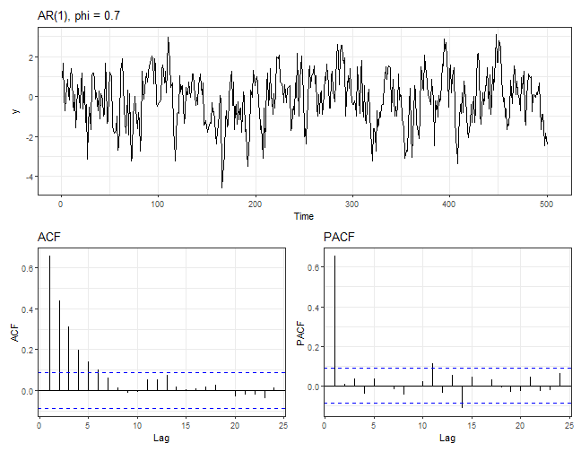

```r
library(forecast); library(ggplot2); library(patchwork)
show_fingerprint <- function(y, title) {
  p1 <- autoplot(y) + ggtitle(title) + theme_bw()
  p2 <- ggAcf(y, lag.max = 24) + ggtitle("ACF") + theme_bw()
  p3 <- ggPacf(y, lag.max = 24) + ggtitle("PACF") + theme_bw()
  p1 / (p2 + p3)
}

set.seed(1985)
y_ar1   <- arma_simulator(n = 500, phi = 0.7)
y_ar2r  <- arma_simulator(n = 500, phi = c(0.5, 0.3))
y_ar2c  <- arma_simulator(n = 500, phi = c(0.6, -0.5))
y_ma1   <- arma_simulator(n = 500, theta = 0.7)
y_ma2   <- arma_simulator(n = 500, theta = c(0.5, 0.4))
y_arma  <- arma_simulator(n = 500, phi = 0.6, theta = 0.4)

show_fingerprint(y_ar1,  "AR(1), phi = 0.7")
```

```r
show_fingerprint(y_ar2r, "AR(2) real roots, phi = (0.5, 0.3)")
```

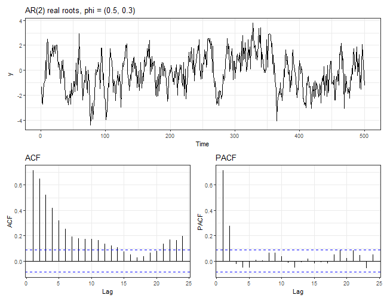

```r
show_fingerprint(y_ar2c, "AR(2) complex roots, phi = (0.6, -0.5)")
```

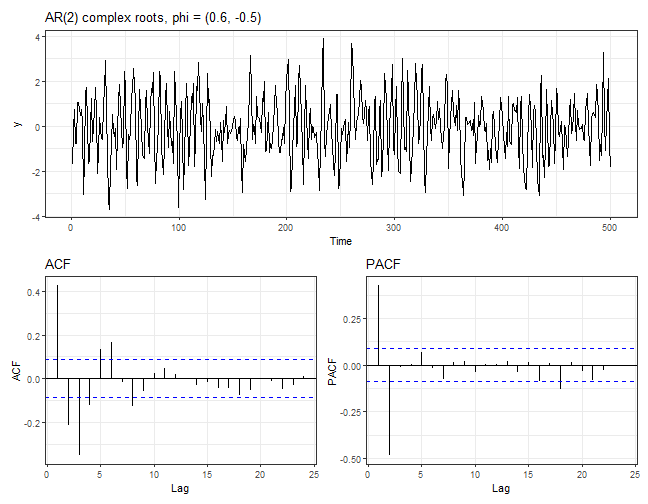

```r
show_fingerprint(y_ma1,  "MA(1), theta = 0.7")
```

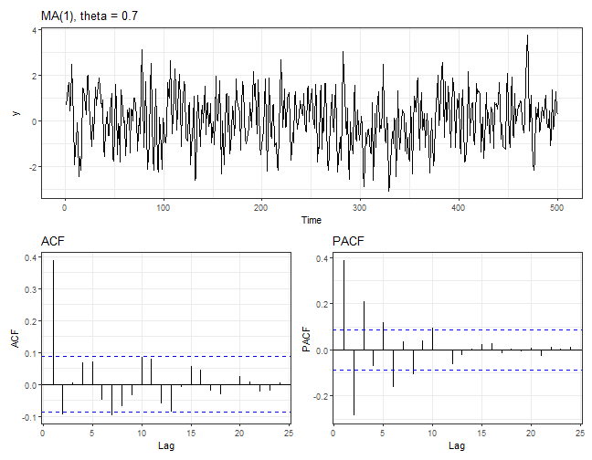

```r
show_fingerprint(y_ma2,  "MA(2), theta = (0.5, 0.4)")
```

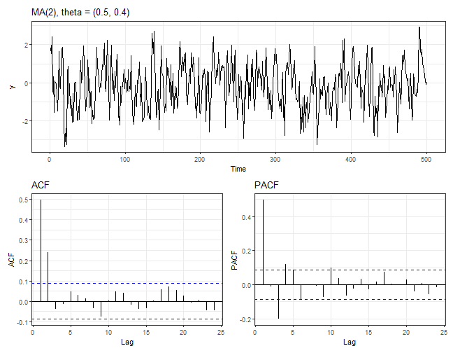

```r
show_fingerprint(y_arma, "ARMA(1,1), phi = 0.6, theta = 0.4")
```

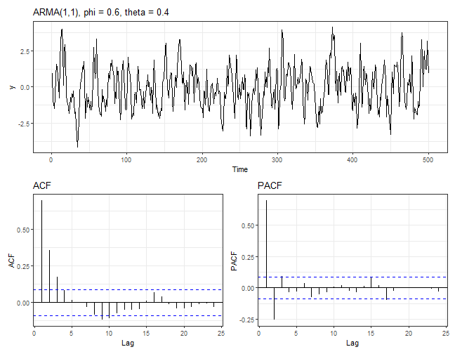

*(`show_fingerprint()` is built live here; it also lives in `helpers/diagnostics.R` as the canonical course copy, so Module 4 onward can `source()` it instead of re-defining it.)*

The first five panels validate the table cleanly. The sixth panel motivates the next module. That is the arc of the simulation gallery: see the rules work, then see the case where they do not decide the question for you.

#### Looking Ahead — The ARMA Tail-Off Problem and Module 4

The ARMA(1,1) panel is the whole motivation for Module 4. The identification rules give you “probably ARMA” but not “ARMA(1,1) versus ARMA(2,1) versus ARMA(1,2).” Module 4 introduces information criteria (AIC and BIC) and residual diagnostics (Ljung-Box) as the tools that let you choose among competing ARMA specifications when the correlogram is ambiguous. Keep this picture in your head when you read that module — you will want to remember what the problem looked like before we had the tools to solve it.

### 3.5.3 Breaking the Assumptions: A Nearly Non-Invertible MA(1)

Everything in the gallery so far shows you what the theory *promises*. This final entry shows you what happens when you push the theory toward its boundary — and it is where the simulation step earns its keep in the four-step ladder (concept → math → simulate → real data). Simulations are not just for confirming that the math works; they are for stressing the math until you can see where it breaks.

The target is an MA(1) with $\theta = -0.97$:

$$y_t = \epsilon_t - 0.97\,\epsilon_{t-1}.$$

On paper, the MA polynomial is $\Theta(L) = 1 - 0.97 L$, which has root $L^{*} = 1/0.97 \approx 1.031$. Technically this is outside the unit circle, so the process is invertible and everything in §3.3 applies. But $L^{*}$ sits right next to $L = 1$, which is the **over-differencing trap** root from §3.3 — and that proximity is going to matter.

The theoretical first-lag autocorrelation is

$$\rho_1 = \frac{\theta}{1 + \theta^{2}} = \frac{-0.97}{1 + 0.9409} \approx -0.4998,$$

essentially the $|\rho_1| \leq 0.5$ boundary we derived earlier. In theory, this is still a clean MA(1): the ACF cuts off at lag 1, all other autocorrelations are zero.

In practice:

```r
set.seed(1999)
y_bad <- arma_simulator(n = 500, theta = -0.97)

show_fingerprint(y_bad, "MA(1), theta = -0.97 — nearly non-invertible")
```

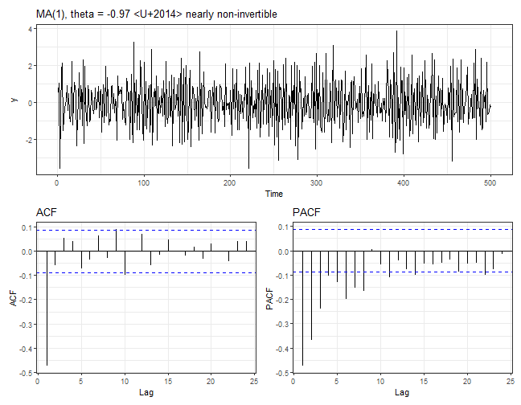

Two things become operationally difficult, and both are worth seeing with your own eyes:

1. **The sample ACF is ragged.** The $\rho_1$ spike is there (big and negative, as expected), but lags 2, 3, 4, … are not exactly zero. That is ordinary sampling variation around population zeros, not a failure of the MA(1) cutoff. The near-boundary value matters most for estimating and interpreting $\theta$, not for changing the population ACF rule.
2. **Boundary estimation becomes delicate.** Try estimating the model you just simulated:

```r
fit_bad <- arima(y_bad, order = c(0, 0, 1))
fit_bad
```

```
##
## Call:
## arima(x = y_bad, order = c(0, 0, 1))
##
## Coefficients:
##          ma1  intercept
##       -1.000    -0.0012
## s.e.   0.009     0.0003
##
## sigma^2 estimated as 0.8816:  log likelihood = -681.08,  aic = 1368.16
```

In this rendered run, $\hat{\theta}$ lands essentially at $-1$, while the printed Hessian-based standard error is small rather than huge. That combination is not reassuring. At a unit-circle boundary the usual interior-parameter likelihood approximation is nonstandard, so the reported standard error and a conventional Wald interval need not be reliable. `stats::arima()` also converts the fitted MA polynomial to an equivalent invertible representation after optimization when `transform.pars = TRUE`; it does not guarantee a convergence warning whenever the estimate piles up at the boundary.

You have now seen the over-differencing trap three times, in three different guises:

- **§2.10 (algebraic)**: differencing a trend-stationary series produced an MA(1) with $\theta = -1$, root exactly on the unit circle.
- **§3.3 (conceptual)**: that is the canonical non-invertible case, and the reason invertibility matters is that MLE needs the roots of $\Theta(L)$ to stay strictly outside the unit circle.
- **§3.5.3 (experimental)**: push $\theta$ close to $-1$ on purpose, watch ordinary sample noise obscure the population cutoff, and watch `arima()` return a boundary estimate whose conventional standard error is not a reliable guide to inference. The theory and the algebra were not abstract warnings; they were predictions, and here are the predictions playing out in the console.

This is the whole point of the simulation step. A clean gallery shows you what works. An assumption-break shows you *why* the assumptions are there. When you later encounter a model estimate where $\hat{\theta}$ comes back near $-1$ — with either a large standard error or a deceptively small one — you will recognize the boundary warning and revisit the differencing and model specification.

## 3.6 Building `arma_simulator()`

This is the Module 3 version of the signature live-coding move from Module 1. In Module 1 we built `ar1_simulator()` from scratch instead of calling `arima.sim()`, on the grounds that typing the DGP into code is how you internalize what a DGP actually *is*. We are going to do the same thing here, but generalized. The function we build is an almost-literal transcription of the master equation into a for-loop.

```r
arma_simulator <- function(
    n = 500,
    alpha = 0,
    phi = c(),
    theta = c(),
    sigma = 1,
    burn_in = 200) {

  p <- length(phi)
  q <- length(theta)
  total <- burn_in + n
  eps <- rnorm(total, 0, sigma)
  y <- numeric(total)

  for (t in seq_len(total)) {
    ar_part <- 0
    if (p > 0 && t > p) {
      ar_part <- sum(phi * y[(t-1):(t-p)])
    }
    ma_part <- 0
    if (q > 0 && t > q) {
      ma_part <- sum(theta * eps[(t-1):(t-q)])
    }
    y[t] <- alpha + ar_part + ma_part + eps[t]
  }

  ts(y[(burn_in + 1):total])
}
```

*(Canonical copy: this function also lives in `helpers/simulators.R`. Per the course’s inline-first policy it is built inline here, in the module where it is born; Module 4 onward will `source()` it from `helpers/` instead of re-defining it.)*

Walk through it block by block.

- **The signature.** `n` is the length of the final returned series, `alpha` is the intercept, `phi` is a vector of AR coefficients (possibly empty), `theta` is a vector of MA coefficients (possibly empty), `sigma` is the innovation standard deviation, and `burn_in` is the number of observations we simulate and then discard at the beginning. The burn-in is there to wash out the effect of the starting values — we initialize $y[1]$ with nothing but $\epsilon_1$, which is not a draw from the stationary distribution, and the first couple of hundred observations carry that contamination. Throwing them away gives us a clean draw from the stationary distribution (approximately, for stationary processes).
- **The setup.** `p` and `q` are the orders of the AR and MA parts. `total` is the total number of observations we actually simulate, including the burn-in. `eps` is the vector of innovations — one call to `rnorm()` for the whole simulation, so they are all drawn up front. `y` is the pre-allocated vector we will fill in.
- **The for-loop.** This is the master equation, one observation at a time. For each $t$, we compute the AR part, the MA part, and the contemporaneous innovation, then add them all together. The guards `t > p` and `t > q` prevent us from indexing off the beginning of the vectors during the first few time steps, where we do not yet have $p$ or $q$ lags of history. You could initialize more carefully (seed with draws from the stationary distribution, or burn in inside the loop), but the burn-in approach is conceptually cleaner and is what most textbook simulators use.

The three lines inside the loop —

```r
ar_part <- sum(phi * y[(t-1):(t-p)])
ma_part <- sum(theta * eps[(t-1):(t-q)])
y[t] <- alpha + ar_part + ma_part + eps[t]
```

— are *literally* the master equation:

$$y_t = \alpha + \sum_{j=1}^{p} \phi_j y_{t-j} + \sum_{l=1}^{q} \theta_l \epsilon_{t-l} + \epsilon_t.$$

There is no hidden algebra, no cleverness. The AR sum is a dot product of `phi` with the last $p$ values of $y$. The MA sum is a dot product of `theta` with the last $q$ innovations. The contemporaneous innovation is $\epsilon_t$. Add them up, store in `y[t]`, increment $t$, repeat. If you can read this for-loop, you can read the master equation, and vice versa.

Once you have internalized the loop, you can (and should) switch to the packaged version for production work. `arima.sim()` is faster, better-tested, and handles edge cases you have not yet thought about:

```r
y_pkg <- arima.sim(n = 500, list(ar = c(0.6, -0.3), ma = c(0.4)))
```

But the home-built version is the pedagogically honest one. When you simulate something and it looks wrong, the first thing to check is whether your understanding of the DGP matches the three lines inside that loop.

## 3.7 Real-Data Application: Differenced US Unemployment

This is the fourth and final step of the ladder: concept, math, simulation, and now **real data**. Every module in this course ends with a look at a FRED series that students would realistically work with, precisely because simulations are clean and real data is not. The gap between them is where most of your judgment as a time series practitioner lives.

In Module 2 we applied the full stationarity workflow to the US civilian unemployment rate from FRED and concluded that, on balance, we should treat the level series as $I(1)$ and work with its first difference. Having spent this module learning to read fingerprints, it is worth asking: what does the ACF/PACF of $\Delta$(unemployment rate) actually look like?

To pull the series live, store your FRED key in the environment (never hardcode it in course files) and run:

```r
library(fredr)
fredr_set_key(Sys.getenv("FRED_KEY"))

unrate <- fredr(series_id = "UNRATE",
                observation_start = as.Date("1948-01-01"))
y <- ts(unrate$value, start = c(1948, 1), frequency = 12)
dy <- diff(y)
```

So that these notes render identically for everyone — with or without an API key or an internet connection — the code below loads the same series from the course’s cached copy in `data/UNRATE.csv` (the same cache Module 2 used). The workflow from here on is identical either way.

```r
library(forecast); library(ggplot2); library(patchwork)

unrate <- read.csv("../data/UNRATE.csv")  # cached FRED pull; see data/README.md
unrate$observation_date <- as.Date(unrate$observation_date)
unrate <- unrate[order(unrate$observation_date), ]

# The cache has one missing month (2025-10, a federal data-release gap).
# Keep the complete run from 1948-01 through the last month before the gap
# so the monthly ts index stays aligned.
first_na <- which(is.na(unrate$UNRATE))
if (length(first_na) > 0) unrate <- unrate[seq_len(min(first_na) - 1), ]

y <- ts(unrate$UNRATE, start = c(1948, 1), frequency = 12)
dy <- diff(y)
```

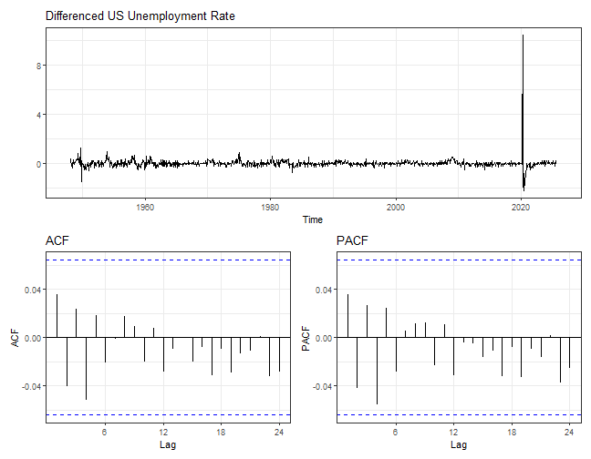

```r
p1 <- autoplot(dy) + theme_bw() +
  labs(title = "Differenced US Unemployment Rate", y = "")
p2 <- ggAcf(dy, lag.max = 24) + theme_bw() + ggtitle("ACF")
p3 <- ggPacf(dy, lag.max = 24) + theme_bw() + ggtitle("PACF")
p1 / (p2 + p3)
```

The full-sample fingerprint is nearly flat: none of the first 24 sample autocorrelations clears the usual approximate band, and $\hat\rho_1 = 0.036$. Read literally, that looks like white noise. But the time plot gives us a reason not to stop at that reading: the unemployment rate jumped 10.4 percentage points in April 2020. That one observation inflates the variance in the denominator of every sample autocorrelation and compresses the whole correlogram toward zero.

The full sample remains the primary evidence. We do not silently delete an inconvenient episode. Instead, we ask a labeled sensitivity question: what structure is visible if we exclude the extraordinary March 2020–December 2021 window?

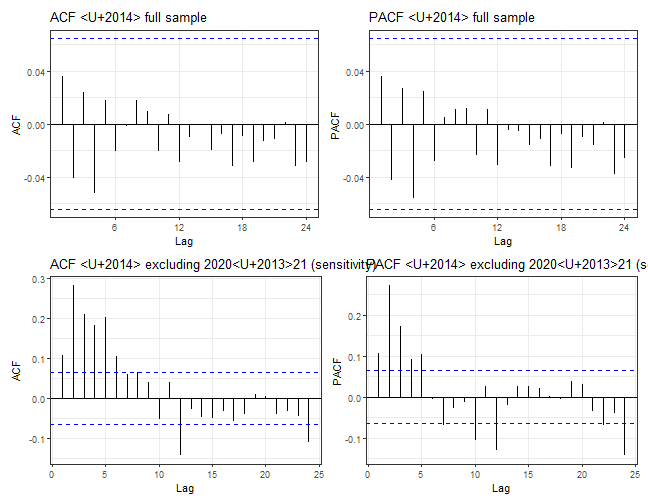

```r
d_dates <- unrate$observation_date[-1]
keep <- !(d_dates >= as.Date("2020-03-01") &
          d_dates <= as.Date("2021-12-01"))
dy_ex_covid <- as.numeric(dy)[keep]

p_full_acf <- ggAcf(dy, lag.max = 24) + theme_bw() +
  ggtitle("ACF — full sample")
p_full_pacf <- ggPacf(dy, lag.max = 24) + theme_bw() +
  ggtitle("PACF — full sample")
p_sens_acf <- ggAcf(dy_ex_covid, lag.max = 24) + theme_bw() +
  ggtitle("ACF — excluding 2020–21 (sensitivity)")
p_sens_pacf <- ggPacf(dy_ex_covid, lag.max = 24) + theme_bw() +
  ggtitle("PACF — excluding 2020–21 (sensitivity)")

(p_full_acf + p_full_pacf) / (p_sens_acf + p_sens_pacf)
```

Real data is honest about being messier than simulations. The identification skill you are building is not “match the picture to the table exactly”; it is “form a defensible first guess, examine why the evidence may be distorted, and then let formal model-selection tools refine the candidates.” Here the full-sample correlogram is the finding, and the exclusion is a transparent diagnostic explaining why that finding is fragile.

**Closing the L2 → L3 arc.** It is worth plotting the *levels* ACF next to the *differenced* ACF to see the whole story in two pictures:

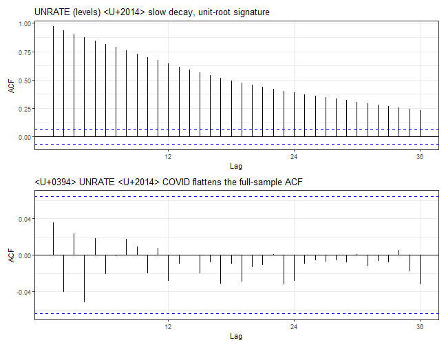

```r
p_levels <- ggAcf(y, lag.max = 36) + theme_bw() +
  ggtitle("UNRATE (levels) — slow decay, unit-root signature")
p_diff   <- ggAcf(dy, lag.max = 36) + theme_bw() +
  ggtitle("Δ UNRATE — COVID flattens the full-sample ACF")
p_levels / p_diff
```

The levels ACF decays glacially — that is the random-walk-like fingerprint you learned to recognize in Module 2, and it is exactly why we differenced. Differencing removes that slow persistence, but it does not guarantee a clean sample fingerprint: in the full sample, the COVID shock masks most of the remaining dependence. The labeled sensitivity analysis reveals plausible low-order ARMA and seasonal structure without pretending that 2020–21 never happened. That is the full L2 → L3 arc: settle the transformation, read the evidence you actually have, probe influential episodes transparently, and carry defensible candidates into Module 4.

## Common Pitfalls and Misconceptions

1. **“An AR(2) is stationary if both $|\phi_1| < 1$ and $|\phi_2| < 1$.”** No. The condition is on the roots of $\Phi(L)$, not on the coefficients individually. Example 2 in §3.2.3 has $|\phi_1| = 0.8 < 1$ and $|\phi_2| = 0.3 < 1$, and is non-stationary.
2. **“An MA process can be non-stationary.”** No. A finite-order MA is always weakly stationary. What it can fail is *invertibility*, which is a different property.
3. **“Stationarity and invertibility are the same thing.”** No. Stationarity lives on the AR side and refers to roots of $\Phi(L)$. Invertibility lives on the MA side and refers to roots of $\Theta(L)$. They are mirror images in form, but they govern different objects.
4. **“If the ACF cuts off at lag 2, the process is AR(2).”** No. An ACF cutoff is the **MA** signature, not the AR signature. An AR(p) cuts off in the **PACF** at lag $p$, not in the ACF.
5. **“Complex characteristic roots mean the model is broken.”** No. Complex roots are fine as long as their modulus is less than one. They produce the characteristic damped-sine ACF and are perfectly stationary — Example 3 in §3.2.3 is stationary.
6. **“$\rho_1$ for an MA(1) can be anything.”** No. The population value is bounded: $|\rho_1| \leq 0.5$. A sample $|\hat{\rho}_1| > 0.5$ is evidence against a pure MA(1), especially as the sample grows, but sampling variation makes it possible even when the DGP is MA(1).
7. **“AR and MA models are fundamentally different families.”** Not quite. A stationary AR(p) has an MA($\infty$) representation; an invertible MA(q) has an AR($\infty$) representation. They are two finite encodings of overlapping families of infinite-order dynamics. We use small finite ARMA for parsimony, not because the classes are mutually exclusive.
8. **“I should always use `arima.sim()` rather than write my own simulator.”** For production work, yes. For learning, building the simulator is how you internalize what the DGP actually is. The three-line loop in `arma_simulator()` is the master equation.

## Connection to Enders

- AR(p) processes and stationarity conditions: Enders Chapter 2, pp. 48–60
- The ACF of AR(p) processes: Enders Chapter 2, pp. 60–66
- MA(q) processes and the ACF cutoff: Enders Chapter 2, pp. 68–72
- Invertibility and AR($\infty$) representations: Enders Chapter 2, pp. 77–78
- The PACF and Yule-Walker equations: Enders Chapter 2, pp. 64–68
- Sample ACF/PACF identification of ARMA models: Enders Chapter 2, pp. 71–80
- Wold decomposition (including the deterministic component): Hamilton Chapter 4, §4.8, pp. 108–109

**A convention warning when you cross-reference.** Enders writes AR coefficients as $a_i$ (his $a_1$ is our $\phi_1$) and states stationarity in terms of characteristic roots lying *inside* the unit circle, where this course uses roots of the lag polynomial $\Phi(L) = 0$ lying *outside* the unit circle — equivalent framings related by $r = 1/L$ (§3.2.2). On the MA side, Enders and Hamilton share our plus-sign convention for $\Theta(L)$, but Box, Jenkins, and Reinsel write the MA polynomial with minus signs, so their $\theta$’s are the negatives of ours (§3.3.1). Hamilton Chapters 3–4 are the rigorous reference for the ACF/PACF results and invertibility; Hyndman & Athanasopoulos cover the same ACF/PACF identification rules from the forecasting-workflow angle, with `forecast`-package examples.

## Practice Problems

### Core Practice

1. **AR(2) roots.** Given an AR(2) with $\phi_1 = 0.4, \phi_2 = 0.2$, compute the discriminant and the characteristic roots by hand. Verify that both roots have modulus less than one, so that the process is stationary. Then simulate the process in R, plot the ACF, and check that the decay rate matches the largest-modulus root.
2. **AR(2) with specified complex modulus.** Find an AR(2) coefficient pair $(\phi_1, \phi_2)$ whose characteristic roots are complex conjugates with modulus exactly 0.9. (Hint: for complex roots $\lambda = a \pm bi$, the characteristic equation is $r^2 - 2ar + (a^2 + b^2) = 0$, so $\phi_1 = 2a$ and $\phi_2 = -(a^2 + b^2)$.) Simulate the process you found, plot its ACF, and describe the oscillatory pattern you see.
3. **MA(2) autocorrelations analytically.** For an MA(2) with $\theta_1 = 0.6, \theta_2 = 0.3$, compute $\rho_0, \rho_1, \rho_2, \rho_3$ analytically by the cross-product method used for the MA(1) in §3.3.3. Then simulate a long MA(2) ($T = 5000$) and compute the sample autocorrelations; verify that they match your analytical values to within sampling error.
4. **The half bound for MA(1).** Show by direct algebra or calculus that $\rho_1 = \theta / (1 + \theta^2)$ cannot exceed 0.5 in absolute value for any real $\theta$. At what values of $\theta$ is the bound attained?
5. **The ARMA(1,1) correlogram trap.** Simulate an ARMA(1,1) with $\phi = 0.5, \theta = 0.5$ ($T = 500$). Plot its ACF and PACF. Comment on what you see, and on why an automated procedure that reads only these two plots would struggle to identify $(p, q) = (1, 1)$ from them directly.
6. **Over-differencing and non-invertibility in practice.** Take an MA(1) with $\theta$ very close to $-1$, say $\theta = -0.99$. Simulate it ($T = 500$). Try to estimate it with `arima(y, order = c(0,0,1))`. What happens to $\hat{\theta}$? What does its reported standard error look like, and why should conventional boundary inference be treated cautiously whether that number is large or small? Relate what you see to the invertibility discussion in §3.3.4 and the L2 over-differencing callback in §3.3.5.
7. **Extend the simulator.** Modify `arma_simulator()` to accept an explicit innovation vector `eps` as an optional argument, so that the user can pass in the same $\epsilon_t$ sequence to multiple parameter configurations and compare the resulting series directly. Use your modified simulator to generate an AR(1) with $\phi = 0.5$ and an AR(1) with $\phi = 0.9$ *driven by the same innovations*, and plot them together. What do you observe?

## Key Takeaways

1. **AR(p) is memory of $y$.** Stationarity requires every root of $\Phi(L) = 1 - \phi_1 L - \ldots - \phi_p L^p$ to lie outside the unit circle; equivalently, every characteristic root of $r^p - \phi_1 r^{p-1} - \ldots - \phi_p = 0$ must lie inside. The ACF tails off and the PACF cuts off at lag $p$.
2. **The AR(2) discriminant** $\phi_1^2 + 4 \phi_2$ distinguishes real roots (smooth ACF decay) from complex roots (damped-sinusoidal ACF). Stationarity is a separate question answered by the modulus of the roots.
3. **MA(q) is memory of shocks.** It is always weakly stationary, with no conditions on the $\theta$’s. It is *invertible* when every root of $\Theta(L) = 1 + \theta_1 L + \ldots + \theta_q L^q$ lies outside the unit circle. The ACF cuts off at lag $q$ and the PACF tails off.
4. **The MA(1) ACF cutoff** comes from cross-product expansion: $\gamma_k$ is zero as soon as $k > q$ because there is no overlap between the innovations in $y_t$ and $y_{t-k}$. The autocorrelation $\rho_1 = \theta / (1 + \theta^2)$ is bounded by $0.5$ in absolute value.
5. **The over-differencing trap** from L2 is the canonical non-invertible MA(1): $\Delta y_t = \delta + \epsilon_t - \epsilon_{t-1}$ has $\Theta(L) = 1 - L$, with a root at $L = 1$ — exactly on the unit circle.
6. **AR $\leftrightarrow$ MA isomorphism.** A stationary AR(p) is an MA($\infty$). More generally, Wold decomposes a covariance-stationary process into deterministic and MA($\infty$) innovation components; purely nondeterministic processes have the pure MA($\infty$) form used here. An invertible MA(q) is an AR($\infty$). A small finite ARMA(p,q) is a compact code for infinite-order dynamics, and that is why a two-parameter ARMA(1,1) can capture behavior that a long AR or a long MA would need many parameters to describe.
7. **The PACF is the second fingerprint.** It is the correlation between $y_t$ and $y_{t-k}$ after removing the linear effect of the intermediate lags; equivalently, the OLS coefficient on the deepest lag in a regression of $y_t$ on $y_{t-1}, \ldots, y_{t-k}$. Use ACF and PACF together.
8. **The identification table.** AR(p): ACF tails, PACF cuts at $p$. MA(q): ACF cuts at $q$, PACF tails. ARMA(p,q): both tail — and that is the Module 4 problem.
9. **Sign conventions.** $\Phi(L) = 1 - \sum \phi_j L^j$ (minus), $\Theta(L) = 1 + \sum \theta_l L^l$ (plus). $\epsilon_t$ for DGP innovations, $e_t$ for residuals of an estimated model. When in doubt, consult notation_dictionary.md.

## Looking Ahead — Module 4

This module ends on a deliberately unresolved note, and the next one picks it up:

- **The ARMA(1,1) “both tail off” trap.** The identification rules decide the pure-AR and pure-MA cases, but the mixed ARMA case blurs both correlograms. Module 4 stops the guessing and lets **information criteria** (AIC and BIC) pick the parsimonious winner among competing specifications.
- **The nearly non-invertible break points forward twice.** Watching `arima()` peg $\hat{\theta}$ near $-1$ previews Module 4’s treatment of **maximum likelihood estimation** at the concept level — enough to read `arima()` output and know when the optimizer is telling you something is wrong. And the practical symptom ($\hat{\theta} \approx -1$ after differencing) returns in Module 5’s **diagnostics** as the over-differencing warning light in a fitted model.

You now have the vocabulary for almost every univariate model in this course. Modules 4 and 5 are about *fitting* and *checking* what you just learned to *write down*.